# General Poisson equation as the minimization problem

This example is an alternative implementation of the *general Poisson equation* example (Jupyter notebook, HTML) and is implemented in the Python file poisson_minimization.py. It illustrates how to:

- Minimize functionals.

## Equation and problem definition

Consider a functional $$E[u] = \int_\Omega d{\bf x} \left[\frac{1}{2} a (\nabla u)^2 - f u \right] - \int_{\Gamma} ds \ g u,$$ with prescribed values $u=u_D$ on $\Gamma_D \subset \Gamma$, where

$\begin{array}{r c l} a &=& 1-\frac{1}{2} (x^2 + y^2),\\ f &=& 1,\\ u_D &=& x,\\ g &=& y.\\ \end{array}$

[figure not shown]

A small variation of the function $u+\delta u$ with $\delta u=0$ on $\Gamma_D$ results in the variation of the functional $E[u+\delta u] = E[u]+\delta E$ where $$\delta E = \int_\Omega d{\bf x} \left[a \nabla u \cdot \nabla \delta u - f \delta u \right] - \int_{\Gamma} ds \ g \delta u.$$

We are searching for the function $u$ that minimizes the functional $E[u]$. In this case, the variation $\delta E$ has to vanish

$\begin{array}{r c l} 0 & =& \int_\Omega d{\bf x} \left[a \nabla u \cdot \nabla \delta u - f \delta u \right] - \int_{\Gamma} ds \ g \delta u,\\ 0 & =& \int_\Omega d{\bf x} \left[- \nabla \cdot (a \nabla u) - f \right] \delta u + \int_{\Gamma} ds \ ({\bf n} \cdot a \nabla u -g) \delta u, \end{array}$

where $\bf n$ is the unit normal vector to the boundary and we used the integration by parts in the second line. Since the variation $\delta u$ is arbitrary, the function $u$ that minimizes the functional $E[u]$ has to satisfy the equations

$\begin{array}{r c c l} \nabla \cdot (a \nabla u) &=& -f & \text{in } \Omega,\\ u &=& u_D & \text{on } \Gamma_D,\\ {\bf n} \cdot a \nabla u &=& g & \text{on } \Gamma_N.\\ \end{array}$

These equations are identical to the ones discussed in the *general Poisson equation* example (Jupyter notebook, HTML).

Note: The variation $\delta u$ plays a similar role as the test function $v$ in the weak formulation of the general Poisson equation.

## Implementation

Following the same steps as in the *general Poisson equation* example (Jupyter notebook, HTML), we import relevant libraries, generate mesh, define function space, the function $u$, the test function $v$, and the functions $a$, $f$, and $g$, and impose Dirichlet boundary conditions $u=u_D$.

```python
from __future__ import print_function
from fenics import *
from mshr import *
import matplotlib.pyplot as plt

# Create mesh
R = 1. # radius
N = 20 # mesh density
domain = Circle(Point(0., 0.), R)
mesh = generate_mesh(domain, N)
#plot(mesh,linewidth=0.3)


#define function space, function u, and test function v
degreeElements = 1
FS = FunctionSpace(mesh, 'Lagrange', degreeElements)
u = Function(FS)
v = TestFunction(FS)

# define functions a and f
a  = Expression('1-0.5*(x[0]*x[0]+x[1]*x[1])', degree=degreeElements)
f  = 1

# define function g
class G(UserExpression):
    def __init__(self, **kwargs):
        super().__init__(**kwargs)
    def eval_cell(self, value, x, ufc_cell):
        value[0]=x[1]
    def value_shape(self):
        return ()

g  = G(degree=degreeElements)


#impose Dirichlet boundary conditions
def right_boundary(x, on_boundary):
    return on_boundary and x[0]>=0

uD = Expression('x[0]',degree=degreeElements)
bc = DirichletBC(FS, uD, right_boundary)
```

Next we define the energy functional $$E[u] = \int_\Omega d{\bf x} \left[\frac{1}{2} a (\nabla u)^2 - f u \right] - \int_{\Gamma} ds \ g u.$$

```python
# functional
E = (1/2*a*dot(grad(u),grad(u))-f*u)*dx - g*u*ds
```

Here `dx` describes the integration over the domain $\Omega$ and `ds` describes the integration over the boundary $\Gamma = \Gamma_D \bigcup \Gamma_N$. Note that we integrated over the entire boundary, because we will use the fact that the variation $\delta u=v=0$ on $\Gamma_D$.

To calculate the variation $\delta E$, we use the `derivate` function, where the first argument is the functional $E[u]$, the second argument is the function $u$, and the third argument is the variation $v=\delta u$. Note that here we use the arbitrary *test function* $v$ in the third argument, which is used by FEniCS to solve the minimization problem.

```python
# solve the problem
Res = derivative(E, u, v)
solve(Res == 0, u, bc)
```

We plot the solution $u$ and calculate ${\boldsymbol \sigma}=a \nabla u$ and $\nabla \cdot {\boldsymbol \sigma}=\nabla \cdot (a \nabla u)$ as was done in the *general Poisson equation* example (Jupyter notebook, HTML).

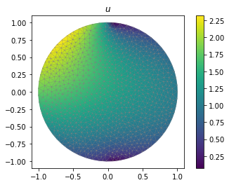

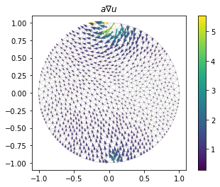

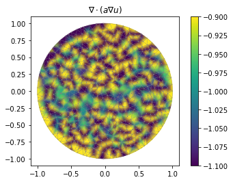

```python
# plot solution
c = plot(u,mode='color',title='$u$')
plt.colorbar(c)
plot(mesh,linewidth=0.3)
plt.show()

# plot a*grad(u)
VFS = VectorFunctionSpace(mesh, 'Lagrange', degreeElements)
sigma=project(a*grad(u),VFS)
c=plot(sigma,title='$a \\nabla u$',width=.008)
plt.colorbar(c)
plot(mesh,linewidth=0.3)
plt.show()

# plot solution for div(a*grad(u))
divSigma = project(div(sigma), FS)
c=plot(divSigma,mode='color',title='$\\nabla \cdot (a \\nabla u)$',vmin=-1.1,vmax=-0.9)
plt.colorbar(c)
plot(mesh,linewidth=0.3)
plt.show()
```

## Complete code

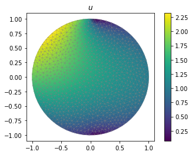

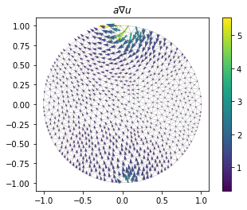

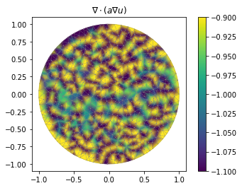

```python
from __future__ import print_function
from fenics import *
from mshr import *
import matplotlib.pyplot as plt

# Create mesh
R = 1. # radius
N = 20 # mesh density
domain = Circle(Point(0., 0.), R)
mesh = generate_mesh(domain, N)


#define function space, function u, and test function v
degreeElements = 1
FS = FunctionSpace(mesh, 'Lagrange', degreeElements)
u = Function(FS)
v = TestFunction(FS)

# define functions a and f
a  = Expression('1-0.5*(x[0]*x[0]+x[1]*x[1])', degree=degreeElements)
f  = 1

# define function g
class G(UserExpression):
    def __init__(self, **kwargs):
        super().__init__(**kwargs)
    def eval_cell(self, value, x, ufc_cell):
        value[0]=x[1]
    def value_shape(self):
        return ()

g  = G(degree=degreeElements)


#impose Dirichlet boundary conditions
def right_boundary(x, on_boundary):
    return on_boundary and x[0]>=0

uD = Expression('x[0]',degree=degreeElements)
bc = DirichletBC(FS, uD, right_boundary)


# functional
E = (1/2*a*dot(grad(u),grad(u))-f*u)*dx - g*u*ds

# solve the problem
Res = derivative(E, u, v)
solve(Res == 0, u, bc)

# plot solution
c = plot(u,mode='color',title='$u$')
plt.colorbar(c)
plot(mesh,linewidth=0.3)
plt.show()

# plot a*grad(u)
VFS = VectorFunctionSpace(mesh, 'Lagrange', degreeElements)
sigma=project(a*grad(u),VFS)
c=plot(sigma,title='$a \\nabla u$',width=.008)
plt.colorbar(c)
plot(mesh,linewidth=0.3)
plt.show()

# plot solution for div(a*grad(u))
divSigma = project(div(sigma), FS)
c=plot(divSigma,mode='color',title='$\\nabla \cdot (a \\nabla u)$',vmin=-1.1,vmax=-0.9)
plt.colorbar(c)
plot(mesh,linewidth=0.3)
plt.show()
```